# Pre-programme Assignment 1

Kris Wu Zhonglong

7th September 2020

# Task 1: Kris’ Biography

## Kris: the Marathoner

I have spent almost *half* of my life away from my family. Having studied in China, Singapore, Europe, the US, I do have acquired a **global awareness**.

My proudest achievements are not academics, internships, or photographs taken. It is my **jogging journey**. I did my first ultra-marathon (50km) at age 20. I consider this the best gift bestowed upon self. Over the years, I did travel and ran a lot.

Top locations that I have ran across

1. Hong Kong 1300 km
2. Singapore 600 km
3. Denmark 240 km
4. London 113 km
5. Paris 68 km

I have not been updating as much about my running experiences. (because I am not running a lot these days, what a shame!)

Nonetheless, feel free to check out my [instagram](https://www.instagram.com/kriswu995/)

# Task 2: `gapminder` country comparison

## Step 1:

Take a `glimpse` of the dataframe (142 countries, from 1952 to 2007) to see the variable names, variable types, etc., and have a look at the first 20 rows of data.

```r
glimpse(gapminder)
```

```
## Rows: 1,704
## Columns: 6
## $ country   <fct> Afghanistan, Afghanistan, Afghanistan, Afghanistan, Afgha...
## $ continent <fct> Asia, Asia, Asia, Asia, Asia, Asia, Asia, Asia, Asia, Asi...
## $ year      <int> 1952, 1957, 1962, 1967, 1972, 1977, 1982, 1987, 1992, 199...
## $ lifeExp   <dbl> 28.801, 30.332, 31.997, 34.020, 36.088, 38.438, 39.854, 4...
## $ pop       <int> 8425333, 9240934, 10267083, 11537966, 13079460, 14880372,...
## $ gdpPercap <dbl> 779.4453, 820.8530, 853.1007, 836.1971, 739.9811, 786.113...
```

```r
head(gapminder, 20) # look at the first 20 rows of the dataframe
```

```
## # A tibble: 20 x 6
##    country     continent  year lifeExp      pop gdpPercap
##    <fct>       <fct>     <int>   <dbl>    <int>     <dbl>
##  1 Afghanistan Asia       1952    28.8  8425333      779.
##  2 Afghanistan Asia       1957    30.3  9240934      821.
##  3 Afghanistan Asia       1962    32.0 10267083      853.
##  4 Afghanistan Asia       1967    34.0 11537966      836.
##  5 Afghanistan Asia       1972    36.1 13079460      740.
##  6 Afghanistan Asia       1977    38.4 14880372      786.
##  7 Afghanistan Asia       1982    39.9 12881816      978.
##  8 Afghanistan Asia       1987    40.8 13867957      852.
##  9 Afghanistan Asia       1992    41.7 16317921      649.
## 10 Afghanistan Asia       1997    41.8 22227415      635.
## 11 Afghanistan Asia       2002    42.1 25268405      727.
## 12 Afghanistan Asia       2007    43.8 31889923      975.
## 13 Albania     Europe     1952    55.2  1282697     1601.
## 14 Albania     Europe     1957    59.3  1476505     1942.
## 15 Albania     Europe     1962    64.8  1728137     2313.
## 16 Albania     Europe     1967    66.2  1984060     2760.
## 17 Albania     Europe     1972    67.7  2263554     3313.
## 18 Albania     Europe     1977    68.9  2509048     3533.
## 19 Albania     Europe     1982    70.4  2780097     3631.
## 20 Albania     Europe     1987    72    3075321     3739.
```

## Step 2:

Perform a `filter` operation on dataframe, to get data sets of China and Asia, where I come from:

```r
country_data <- gapminder %>%
            filter(country == "China")

continent_data <- gapminder %>%
            filter(continent == "Asia")
```

## Step 3:

Create a plot of life expectancy over time for China, **without** titles and labels.

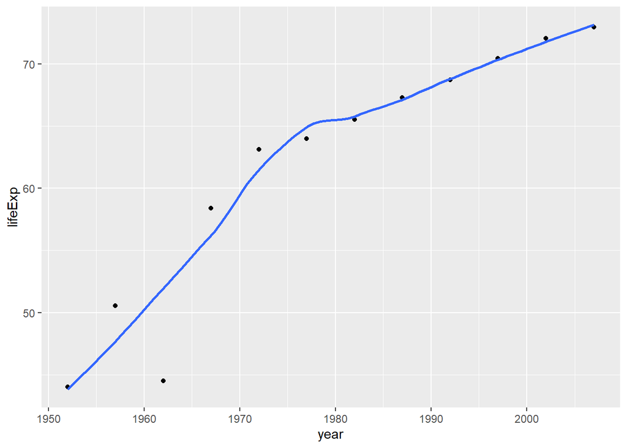

```r
 plot1 <- ggplot(data = country_data, mapping = aes(x = year, y = lifeExp))+
   geom_point() +
   geom_smooth(se = FALSE)+
   NULL
 plot1
```

## Step 4:

Create a new plot of life expectancy over time for China, **with** titles and labels.

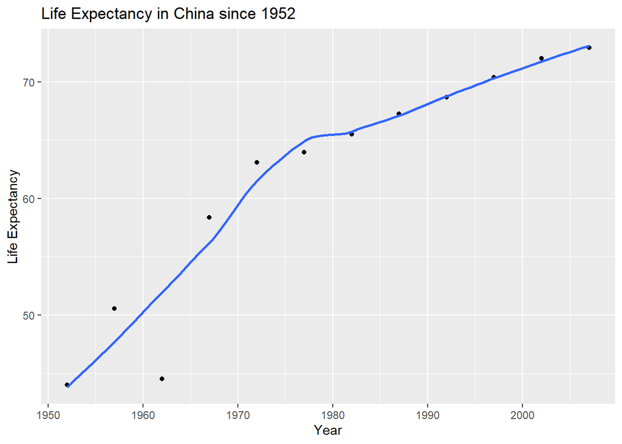

```r
 plot1 <- ggplot(data = country_data, mapping = aes(x = year, y = lifeExp))+
   geom_point() +
   geom_smooth(se = FALSE) +
   labs(title = "Life Expectancy in China since 1952",
       x = "Year",
       y = "Life Expectancy") +
   NULL
 plot1
```

## Step 5:

Produce a plot for all countries in the *Asia* continent, differentiate them by colours.

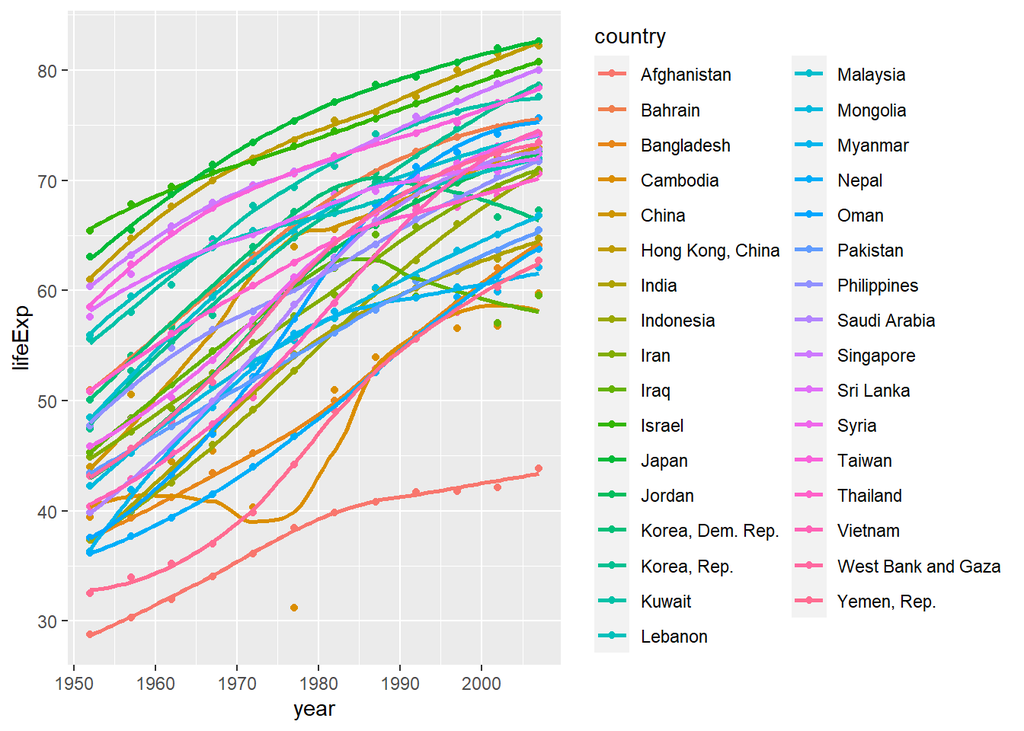

```r
 ggplot(data = continent_data , mapping = aes(x = year, y = lifeExp, colour= country))+
   geom_point() +
   geom_smooth(se = FALSE) +
   NULL
```

## Step 6:

Using the original `gapminder` data, produce a life expectancy over time graph, grouped (or faceted) by continent.

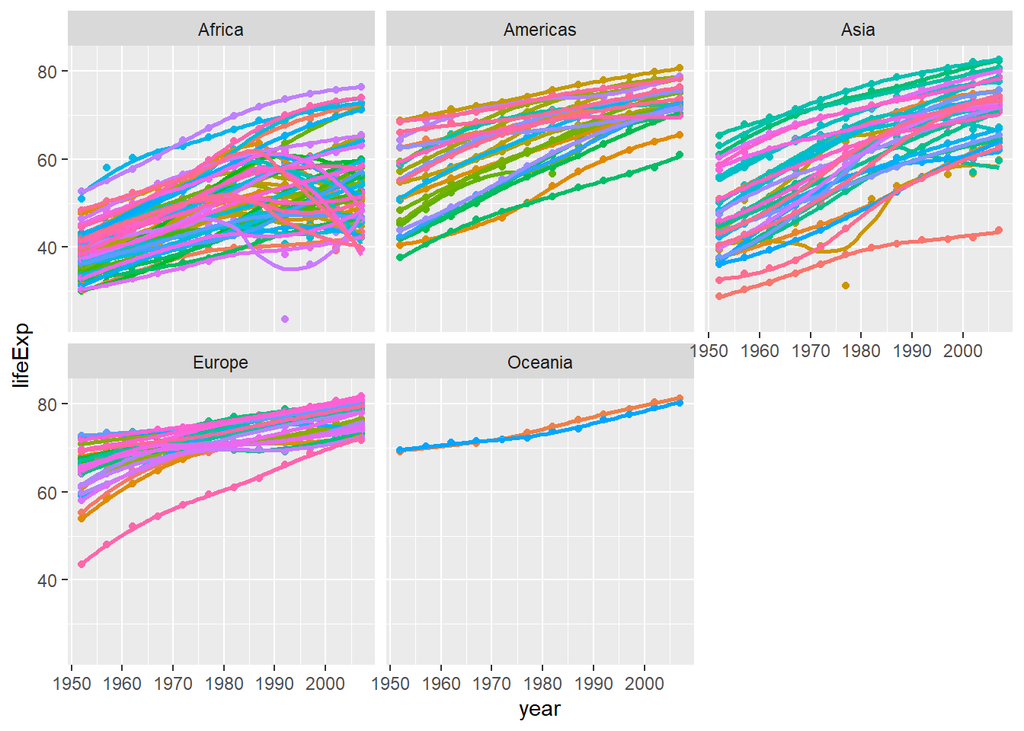

```r
ggplot(data = gapminder , mapping = aes(x = year, y = lifeExp, colour= country))+
geom_point() +
geom_smooth(se = FALSE) +
facet_wrap(~continent) +
theme(legend.position="none") +
NULL
```

## Question:

Given these trends, what can you say about life expectancy since 1952? Again, don’t just say what’s happening in the graph. Tell some sort of story and speculate about the differences in the patterns.

> Life expectancy for all continents is generally rising since 1952. It is perhaps because over the years, GDP per capita for most countries are rising (refer to graph below). A higher income offers access to better nutrition and healthcare, which in turn improve longevity. The increases in life expectancy for most countries are slowing down though. This may be because there is only a limit to which lifespan may increase. And higher living standards could lead to wealth-related problems such as obesity and cardiovascular diseases, that adversely impact one’s health. Some African countries experienced declines likely due to civil wars that destroy lives prematurely.

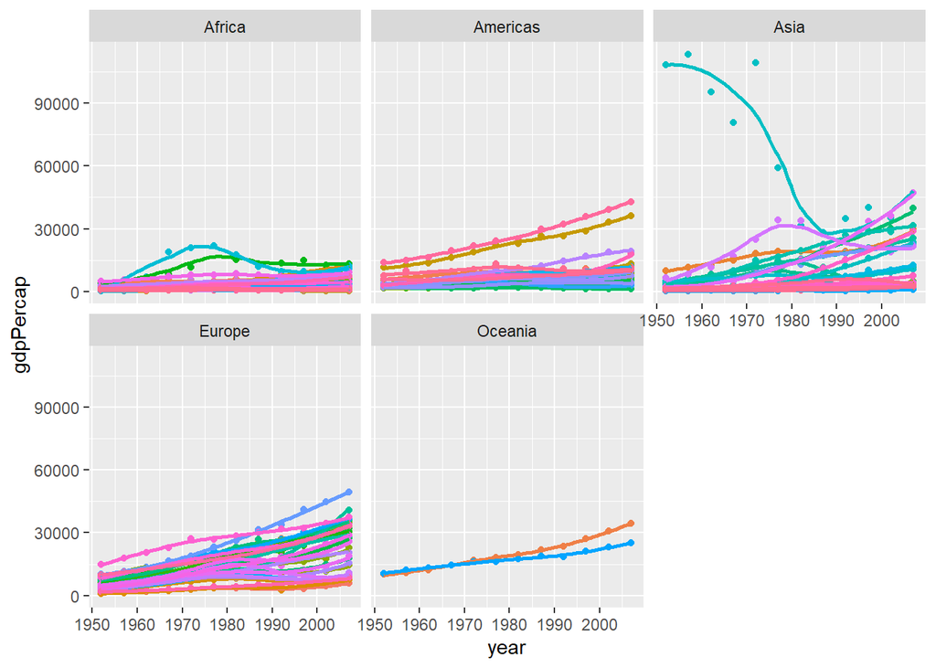

```r
ggplot(data = gapminder , mapping = aes(x = year, y = gdpPercap, colour= country))+
geom_point() +
geom_smooth(se = FALSE) +
facet_wrap(~continent) +
theme(legend.position="none") +
NULL
```

# Task 3: Brexit voting

## Source Acknowledgement

Data: Brexit Election Results  
Data Structure: 632 rows of [parliament constituency](https://en.wikipedia.org/wiki/United_Kingdom_Parliament_constituencies) by 11 columns of constituency attributes (including % votes cast in favour of Brexit, % residents born in the UK, male ratio, unemployment rate, etc.)  
Creator: [Elliott Morris](https://www.thecrosstab.com/)  
Available from: [DataCamp class on analysing election and polling data in R](https://www.datacamp.com/courses/analyzing-election-and-polling-data-in-r)

## Step 1:

Read the data using `read_csv()` and have a quick `glimpse` at the data.

```r
brexit_results <- read_csv(here::here("Data","brexit_results.csv"))
glimpse(brexit_results)
```

```
## Rows: 632
## Columns: 11
## $ Seat        <chr> "Aldershot", "Aldridge-Brownhills", "Altrincham and Sal...
## $ con_2015    <dbl> 50.592, 52.050, 52.994, 43.979, 60.788, 22.418, 52.454,...
## $ lab_2015    <dbl> 18.333, 22.369, 26.686, 34.781, 11.197, 41.022, 18.441,...
## $ ld_2015     <dbl> 8.824, 3.367, 8.383, 2.975, 7.192, 14.828, 5.984, 2.423...
## $ ukip_2015   <dbl> 17.867, 19.624, 8.011, 15.887, 14.438, 21.409, 18.821, ...
## $ leave_share <dbl> 57.89777, 67.79635, 38.58780, 65.29912, 49.70111, 70.47...
## $ born_in_uk  <dbl> 83.10464, 96.12207, 90.48566, 97.30437, 93.33793, 96.96...
## $ male        <dbl> 49.89896, 48.92951, 48.90621, 49.21657, 48.00189, 49.17...
## $ unemployed  <dbl> 3.637000, 4.553607, 3.039963, 4.261173, 2.468100, 4.742...
## $ degree      <dbl> 13.870661, 9.974114, 28.600135, 9.336294, 18.775591, 6....
## $ age_18to24  <dbl> 9.406093, 7.325850, 6.437453, 7.747801, 5.734730, 8.209...
```

## Step 2:

Plot a histogram and a density plot of the leave share in all constituencies

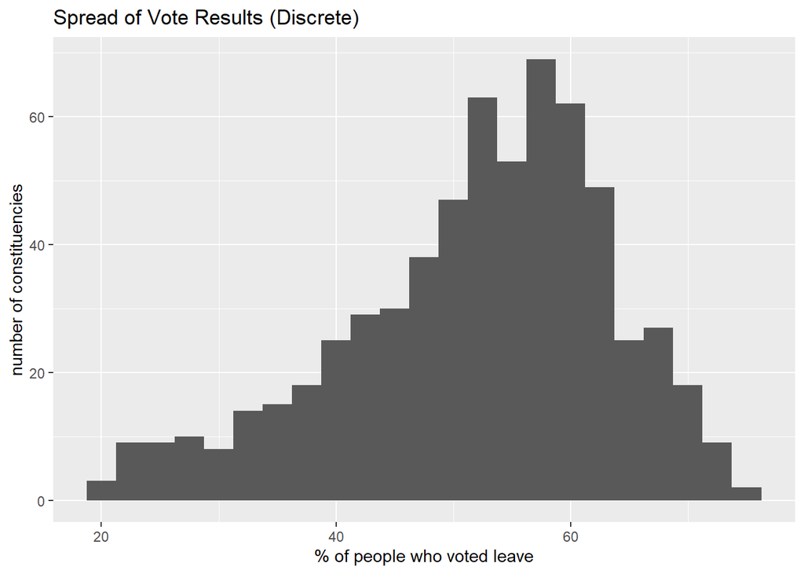

```r
ggplot(brexit_results, aes(x = leave_share)) +
  geom_histogram(binwidth = 2.5) +
  labs(title = "Spread of Vote Results (Discrete)",
       x = "% of people who voted leave",
       y = "number of constituencies")
```

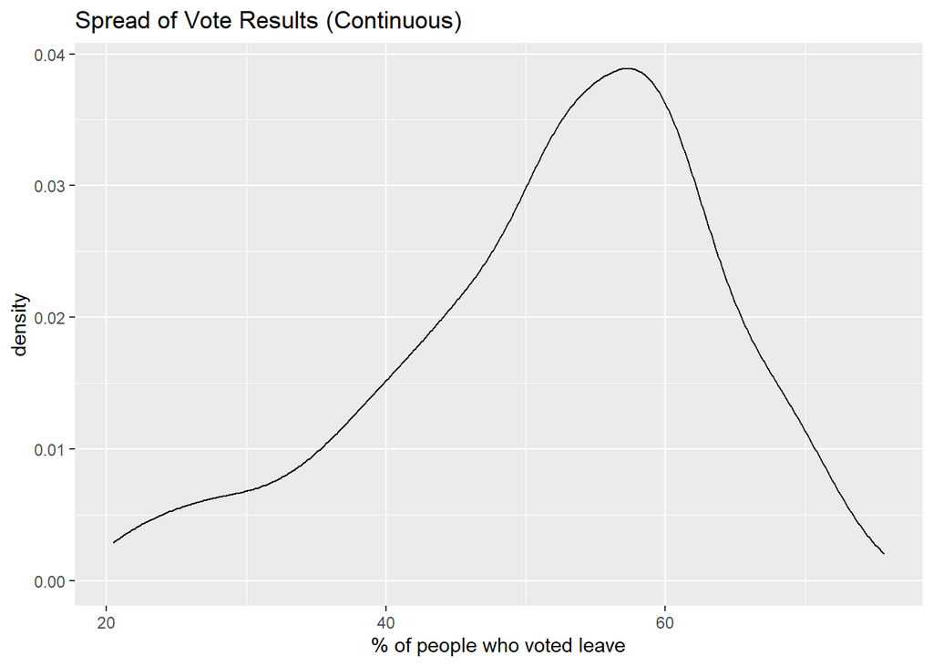

```r
ggplot(brexit_results, aes(x = leave_share)) +
  geom_density() +
  labs(title = "Spread of Vote Results (Continuous)",
       x = "% of people who voted leave",
       y = "density")
```

## Step 3:

Check the relationship (or correlation) between the proportion of native born residents (`born_in_uk`) in a constituency and its `leave_share`

```r
brexit_results %>%
  select(leave_share, born_in_uk) %>%
  cor()
```

```
##             leave_share born_in_uk
## leave_share   1.0000000  0.4934295
## born_in_uk    0.4934295  1.0000000
```

The correlation is almost 0.5, which shows that the two variables are positively correlated.

## Step 4:

Visualize the correlation, by creating a scatterplot between these two variables using `geom_point`. Add the best fit line, using `geom_smooth(method = "lm")`.

## Step 5:

Add `labs()` function to add an informative title, subtitle, and axes titles to all plots.

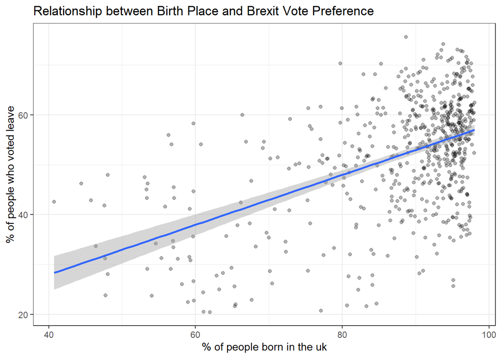

```r
ggplot(brexit_results, aes(x = born_in_uk, y = leave_share)) +
  geom_point(alpha=0.3) +
  geom_smooth(method = "lm") +
  labs(title = "Relationship between Birth Place and Brexit Vote Preference",
       x = "% of people born in the uk",
       y = "% of people who voted leave") +
  theme_bw() +
  NULL
```

## Question:

What can you say about the relationship shown above? Again, don’t just say what’s happening in the graph. Tell some sort of story and speculate about the differences in the patterns.

> The scatters show a general upward trend, meaning that the higher proportion of native born voters, the more likely votes in favor of leave prevail. This observation could indicate that native born voters prefer a non-Europe identity. There are also significant segments where a large proportion is native and yet they prefer to stay in the EU. They perhaps welcome diversity and value the benefits of the EU over the costs. The best-fit line shows a positive correlation, confirming the general observation.

## Details

- Who did you collaborate with: No one
- Approximately how much time did you spend on this problem set: 2 hours
- What, if anything, gave you the most trouble: I accidentally made some typos and additional spaces. So I had to read line by line to identify the error.